# DS250 - Introduction to Data Science

Kevin Niemann

November 10, 2015

### Assignment 6 - Introduction to Machine Learning

This assignment introduces the core concepts and tools used for automated prediction using Machine Learning. The concepts covered in this assignment include supervised and un-supervised learning algorithms, feature analysis, dimensionalality reduction, primary component analysis, statistical validation, and results evalution using ROC plots.

#### The objectives of this assignment are:

- Understand the types of machine learning
- Evaluate and prepare test and training data
- Define and adjust model parameters
- Evaluate model performance

#### Question 1 - Machine Learning

**a**. Briefly describe three differences between Supervised and Unsupervised Machine Learning:

```
Supervised is learning by example. The algorithm needs to be shown a training set before it can predict whether a new data point is part of that set.
Unsupervised is learning by categorizing data you've never seen before. By showing the algorithym different data sets, it will break these into classes without any prior knowledge.
```

**b**. What does the term ‘dimensionality reduction’ mean? Describe some of the activities involved.

```
It is the process of reducing the number of variables under consideration. Some activities might include eliminating a column with too many missing values, or values that don't change often.
```

**c**. Describe some common approaches for identifying contributing variables:

```
Filter methods: Measure the feature by how it statistically impacts the dependent variable and keep or remove it.
Wrapper methods: Tests different combinations of features as search problems and assigns a score to each based on accuracy.
Embedded methods: Learn which features contribute to the accuracy of the model while it is being created.
```

#### Question 2 - Machine Learning

**a**. Describe ‘overfitting’ and some approaches to address it.

```
Overfitting occurs when a model is trying to predict noise instead of the actual variable. Usually the training has been performed too long or there aren't enough training examples.
```

**b**. Describe ‘underfitting’ and some of the approaches to address it.

```
Underfitting means that the model is too simple to describe the data it represents. It needs more training examples or longer time in training.
```

**c**. What are ‘training’ and ‘testing’ data sets. Why can’t a training data set be used to model evaluation?

```
Training set is used to build the model and provide it with information. The test set is used to validate the model functions correctly. Training set can't be used because the model already knows about that information.
```

#### Question 3 - Linear Regression

**a**. Load sample data set: Temperature and Ice Cream sales

```r
icecream <- data.frame(
   temp=c(11.9, 14.2, 15.2, 16.4, 17.2, 18.1,
          18.5, 19.4, 22.1, 22.6, 23.4, 25.1),
  units=c(185L, 215L, 332L, 325L, 408L, 421L,
          406L, 412L, 522L, 445L, 544L, 614L)
  )
```

**b**. Create a plot units of ice cream sold by temperature

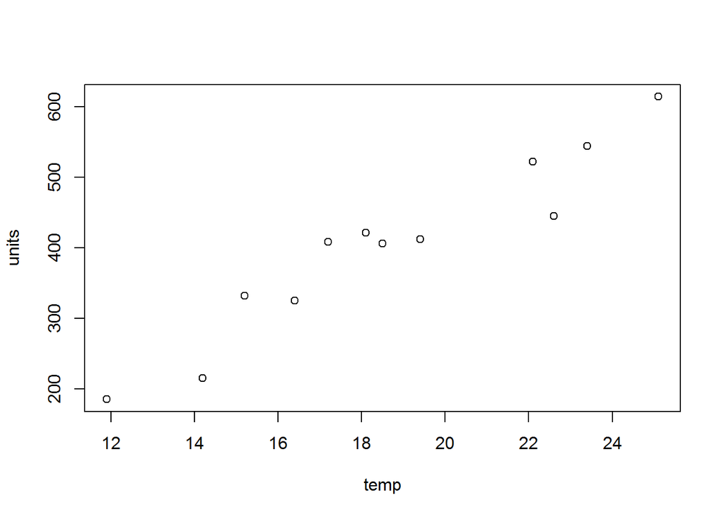

```r
plot(icecream)
```

**c**. Create a regression model (*lm or glm*) for the **icecream** data set and print the model summary

```r
icecreamfit <- lm(units ~ temp, data=icecream)
summary(icecreamfit)
```

```
##
## Call:
## lm(formula = units ~ temp, data = icecream)
##
## Residuals:
##     Min      1Q  Median      3Q     Max
## -75.512 -12.566   4.133  22.236  49.963
##
## Coefficients:
##             Estimate Std. Error t value Pr(>|t|)
## (Intercept) -159.474     54.641  -2.919   0.0153 *
## temp          30.088      2.866  10.499 1.02e-06 ***
## ---
## Signif. codes:  0 '***' 0.001 '**' 0.01 '*' 0.05 '.' 0.1 ' ' 1
##
## Residual standard error: 38.13 on 10 degrees of freedom
## Multiple R-squared:  0.9168, Adjusted R-squared:  0.9085
## F-statistic: 110.2 on 1 and 10 DF,  p-value: 1.016e-06
```

**d**. Plot the **icecream** regression model including the confidence intervals

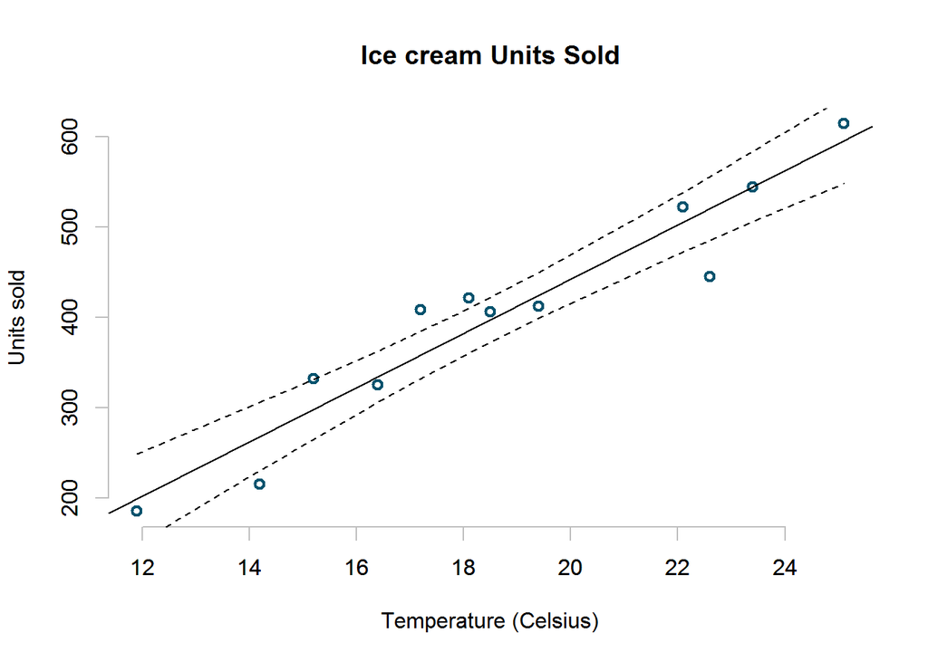

```r
plot(units ~ temp, data=icecream, bty="n", lwd=2,
     main="Ice cream Units Sold", col="#00526D",
     xlab="Temperature (Celsius)",
     ylab="Units sold")
axis(side = 1, col="grey")
axis(side = 2, col="grey")

abline(icecreamfit)
conf <- predict(icecreamfit, interval="confidence")
lines(icecream$temp, conf[,2], lty=2)
lines(icecream$temp, conf[,3], lty=2)
```

```r
students <- read.csv("http://www.ats.ucla.edu/stat/data/binary.csv")
```

**b**. Create a logistic regression model using (*glm*) for student admissions

```r
fit = glm(admit~ gre+gpa+rank, family=binomial, data=students)
summary(fit)
```

```
##
## Call:
## glm(formula = admit ~ gre + gpa + rank, family = binomial, data = students)
##
## Deviance Residuals:
##     Min       1Q   Median       3Q      Max
## -1.5802  -0.8848  -0.6382   1.1575   2.1732
##
## Coefficients:
##              Estimate Std. Error z value Pr(>|z|)
## (Intercept) -3.449548   1.132846  -3.045  0.00233 **
## gre          0.002294   0.001092   2.101  0.03564 *
## gpa          0.777014   0.327484   2.373  0.01766 *
## rank        -0.560031   0.127137  -4.405 1.06e-05 ***
## ---
## Signif. codes:  0 '***' 0.001 '**' 0.01 '*' 0.05 '.' 0.1 ' ' 1
##
## (Dispersion parameter for binomial family taken to be 1)
##
##     Null deviance: 499.98  on 399  degrees of freedom
## Residual deviance: 459.44  on 396  degrees of freedom
## AIC: 467.44
##
## Number of Fisher Scoring iterations: 4
```

**c**. Plot the student regression model including confidence intervals

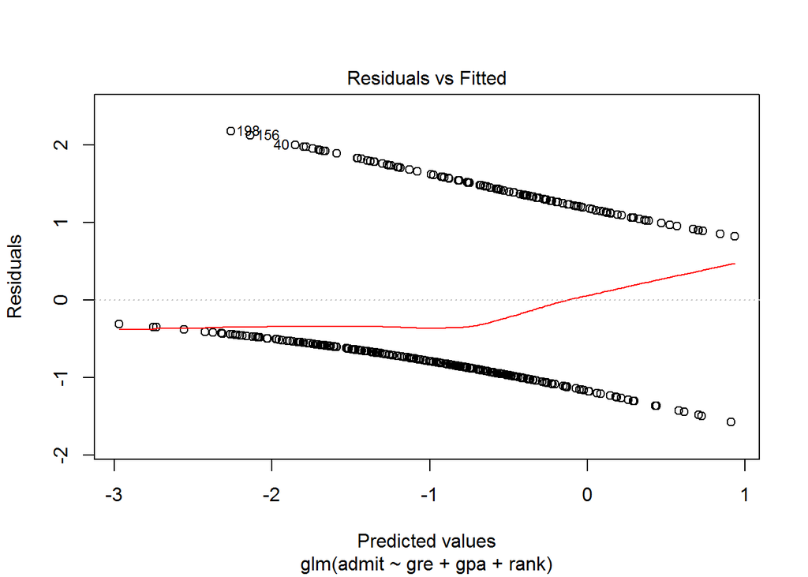

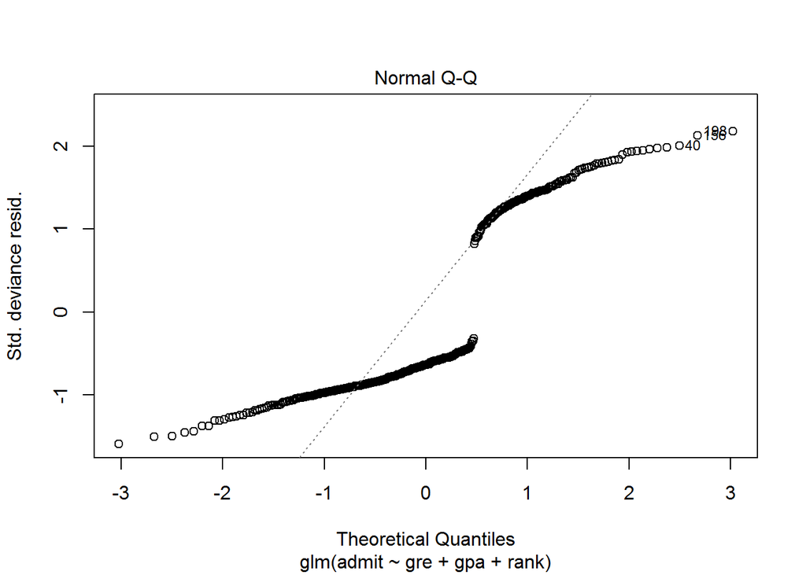

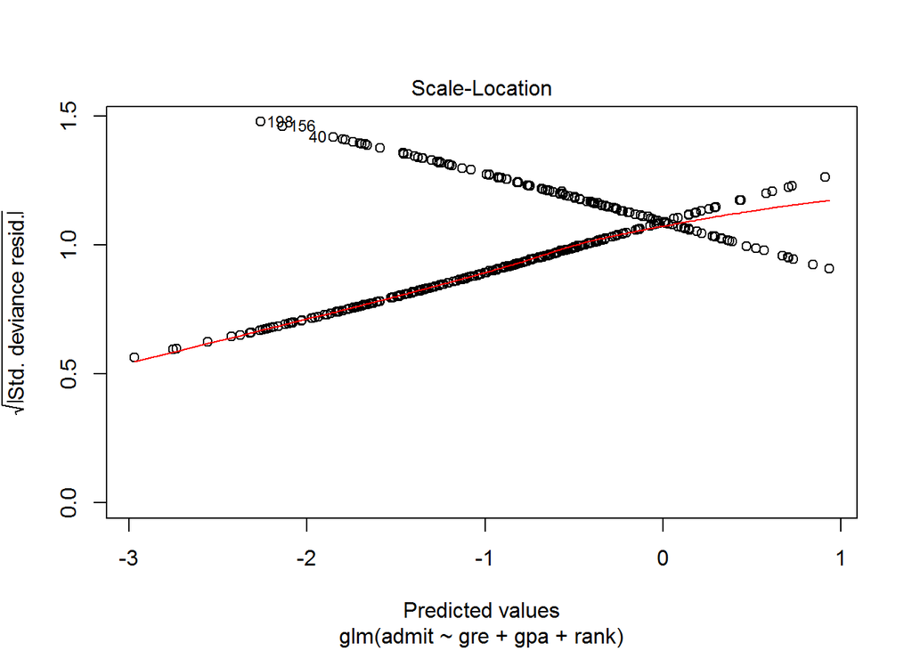

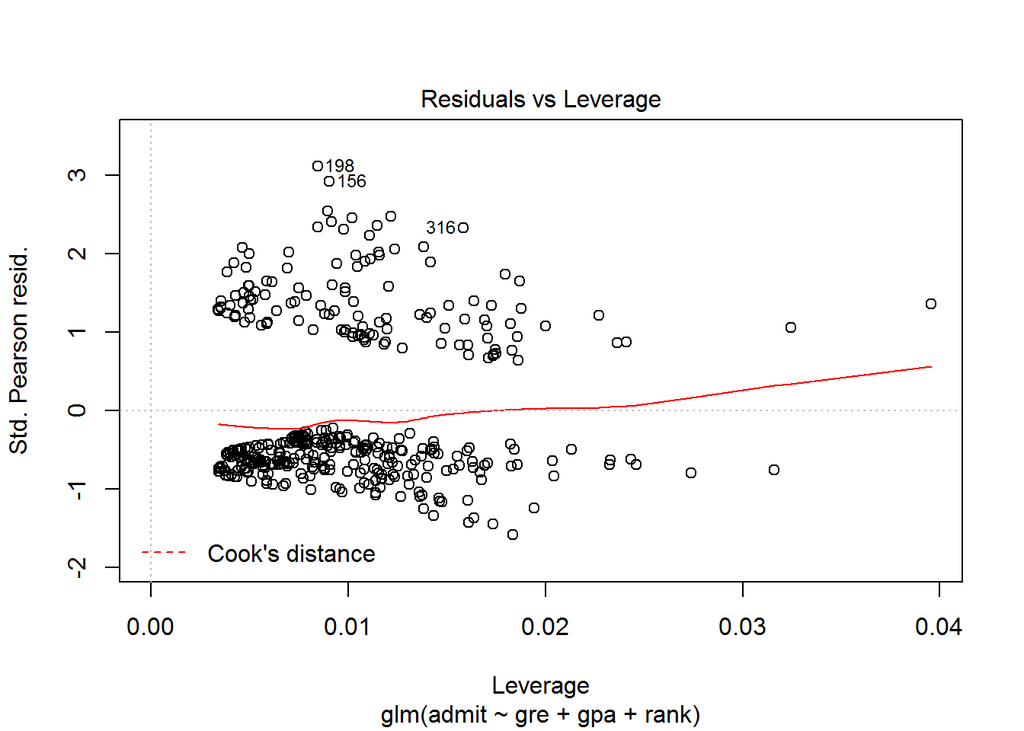

```r
plot(fit)
```

#### Question 5 - Supervised Learning

**a**. Using R, classify two data sets using kNN (Nearest Neighbor):

```r
library(class)    #k-nearest neighbors

library(kknn)     #weighted k-nearest neighbors
# Class A
A1=c(0,0)
A2=c(1,1)
A3=c(2,2)

# Class B
B1=c(6,6)
B2=c(5.5,7)
B3=c(6.5,5)

train=rbind(A1,A2,A3, B1,B2,B3)
```

**b**. From the model in **a**, test the kNN model against a different test value:

> test=c(3.5, 3.5) # is this an A or B?

```r
test=c(3.5, 3.5)
cl=factor(c(rep("A",3),rep("B",3)))
summary(knn(train, test, cl, k = 1))
```

```
## A B
## 1 0
```

It belongs to group A.

**c**. Create a scatter plot showing the A and B class objects and the test objects.

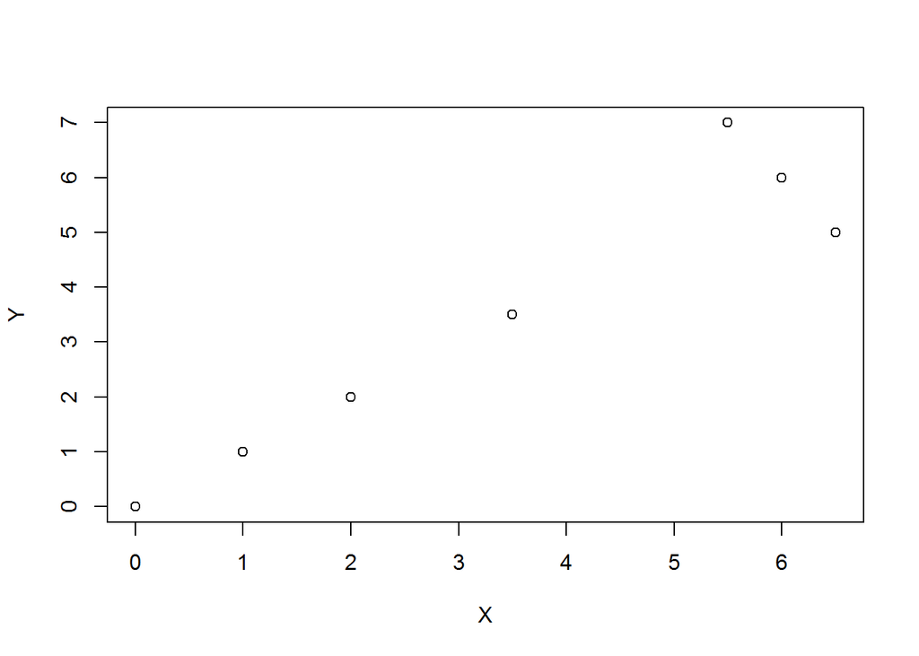

```r
traintest=rbind(train, test)
plot(traintest, xlab="X", ylab="Y")
```

#### Question 6 - Cluster Analysis

**a**. Identify the number of clusters in the following data and plot the data points.

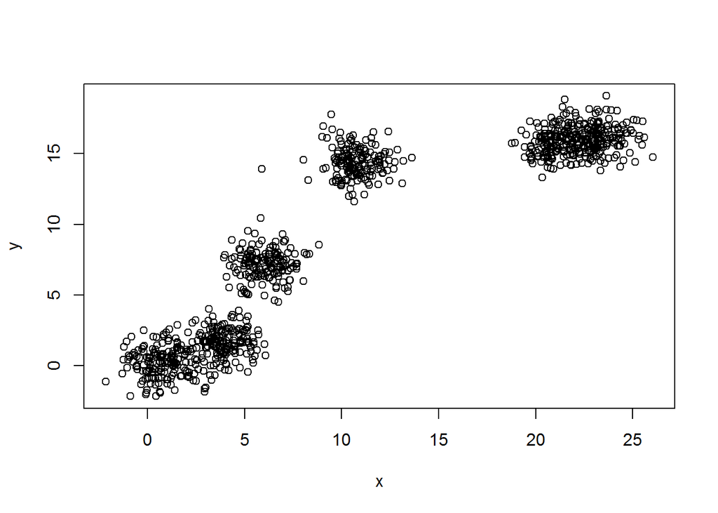

```r
n = 1000
g = 6
set.seed(g)
d <- data.frame(x = unlist(lapply(1:g, function(i) rnorm(n/g, runif(1)*i^2))),
                y = unlist(lapply(1:g, function(i) rnorm(n/g, runif(1)*i^2))))
plot(d)
```

**b**. Exploratory Data Analysis - Create scatterplot showing cluster distribution

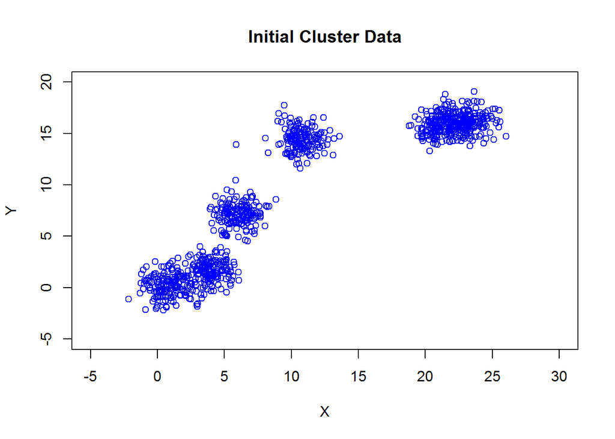

```r
plot(d, type = "p", col="blue", xlim=c(-5,30), ylim=c(-5,20),
main="Initial Cluster Data", xlab="X", ylab="Y")
```

**c**. Cluster Analysis - Calculate the ‘Within Groups Sum of Squares’ to estimate optimal ‘K’

```
NbClust(d, min.nc=2, max.nc=15, method="kmeans")
Optiomal k = 3
```

**d**. Model - Create K-Means model and display fit results.

```r
set.seed(1234)
km=kmeans(d,3,nstart=25)
table(km$cluster)
```

```
##
##   1   2   3
## 177 332 487
```

#### Question 7 - Cluster Analysis

**a**. Retrieve sample data from: (http://archive.ics.uci.edu/ml/machine-learning-databases/wine)

```r
wine.data <- read.csv("http://archive.ics.uci.edu/ml/machine-learning-databases/wine/wine.data")

colnames(wine.data) <- c("Region", "Alcohol", "Malic Acid", "Ash","Alcalinity", "Magnesium", "Total Phenols","Flavanoids", "Nonflavanoid Phenols","Proanthocyanins", "Color", "Hue","OD280/OD315", "Proline")
```

**b**. Cluster Analysis - Determine optimal number of clusters

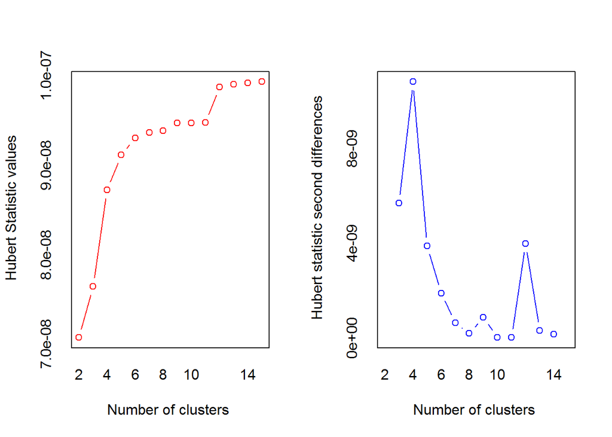

```
## *** : The Hubert index is a graphical method of determining the number of clusters.
##                 In the plot of Hubert index, we seek a significant knee that corresponds to a
##                 significant increase of the value of the measure i.e the significant peak in Hubert
##                 index second differences plot.
##
```

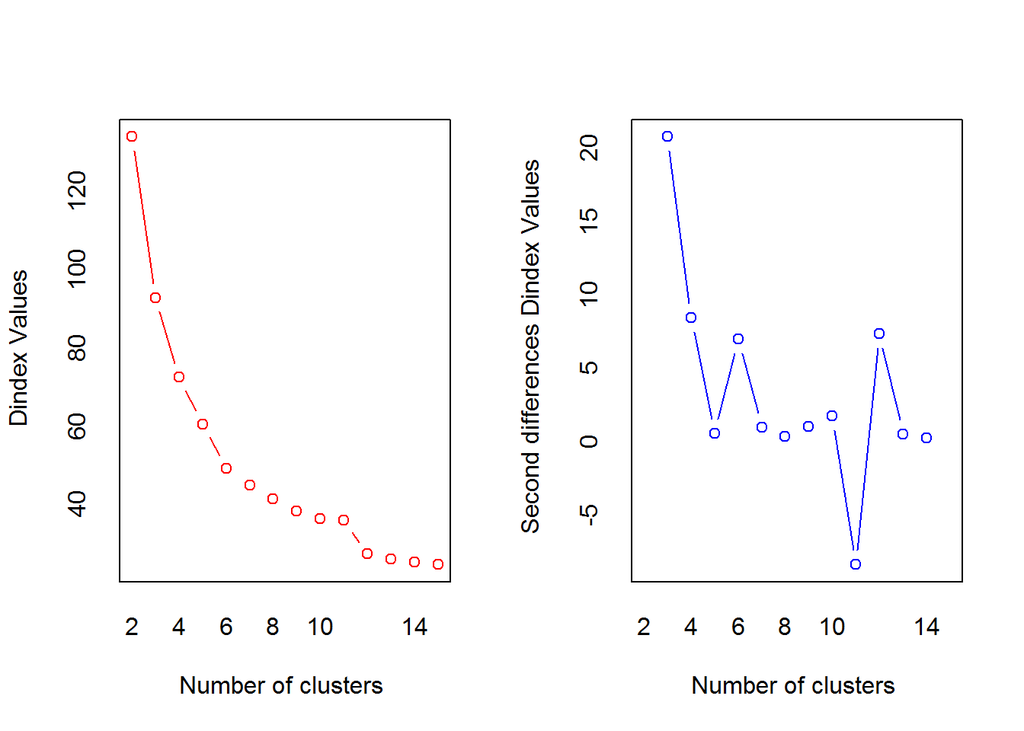

```
## *** : The D index is a graphical method of determining the number of clusters.
##                 In the plot of D index, we seek a significant knee (the significant peak in Dindex
##                 second differences plot) that corresponds to a significant increase of the value of
##                 the measure.
##
## * Among all indices:
## * 10 proposed 2 as the best number of clusters
## * 3 proposed 3 as the best number of clusters
## * 2 proposed 4 as the best number of clusters
## * 1 proposed 10 as the best number of clusters
## * 1 proposed 11 as the best number of clusters
## * 6 proposed 12 as the best number of clusters
## * 1 proposed 15 as the best number of clusters
##
##                    ***** Conclusion *****
##
## * According to the majority rule, the best number of clusters is  2
##
##
```

[output not shown]

[output cut: 88 more lines]

Two clusters

**c**. Evaluate model fit results

```
##
##   1   2
##  54 123
```

#### Evaluate clusters

```
##     Region  Alcohol Malic Acid      Ash Alcalinity Magnesium Total Phenols
## 1 1.111111 13.65611   1.873704 2.427778   17.48704 105.90741      2.816481
## 2 2.308943 12.70285   2.544553 2.339106   20.40813  96.81301      2.062114
##   Flavanoids Nonflavanoid Phenols Proanthocyanins    Color       Hue
## 1   2.893519            0.2931481        1.889630 5.518148 1.0671481
## 2   1.641463            0.3926829        1.454065 4.851382 0.9086179
##   OD280/OD315   Proline
## 1    3.050926 1153.3333
## 2    2.408211  565.8699
```

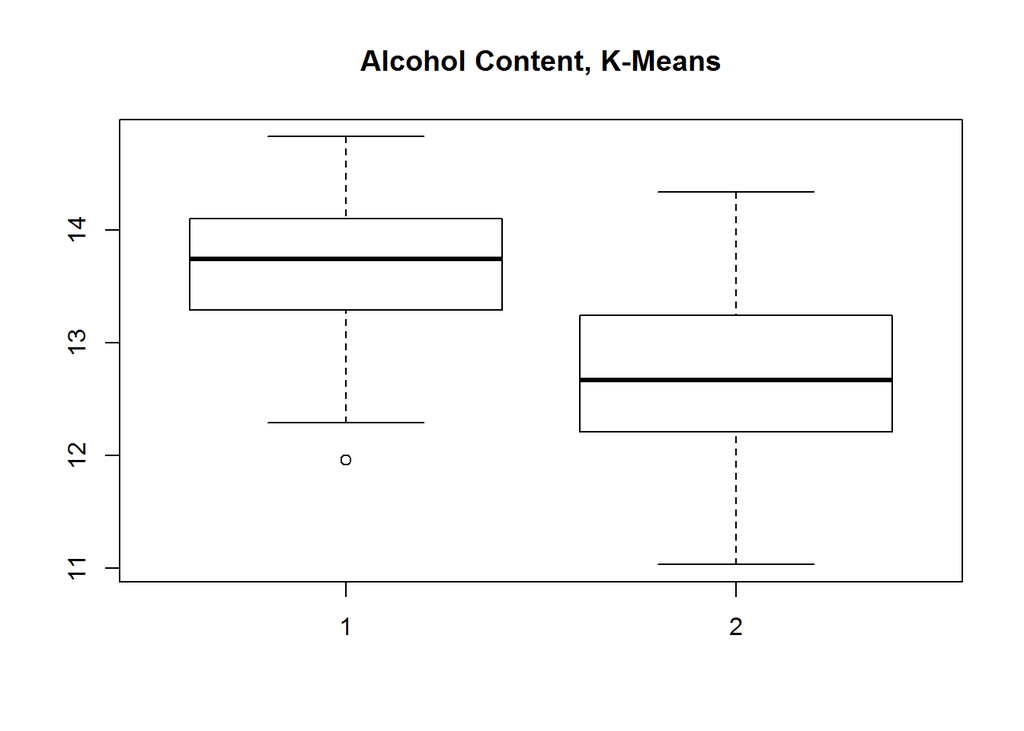

#### BONUS Question (Optional)

**a**. Using the Group Lens Movie data set (ML100k), create a recommendation model that takes a single movie name input and returns a list of ten (10) recommended movies names. (http://www.grouplens.org/system/files/ml-100k.zip)